# stroke

## Import Library

```r
library(tidyverse)
library(readxl)
library(rms)
```

## Read & Clean Data

```r
setwd("C:/UBC MBAN Coursework/3 BABS 508 Advanced Predictive Business Analytics/Project")
dat <- read_excel('Stroke.xlsx')
# dat <- read.csv('Stroke.csv')
dim(dat) # Check dimension
```

```
## [1] 523  12
```

```r
dat <- na.omit( dat )
dat <- dat %>% filter(bmi != 'N/A') # Remove rows with 'N/A' bmi value
dim(dat) # Check dimension after removing missing values
```

```
## [1] 502  12
```

## Explore Data

```r
d <- describe(dat)
html(d, size = 80, scroll = TRUE)
```

dat  
12 Variables 502 Observations

id

| n | missing | distinct | Info | Mean | Gmd | .05 | .10 | .25 | .50 | .75 | .90 | .95 |
| --- | --- | --- | --- | --- | --- | --- | --- | --- | --- | --- | --- | --- |
| 502 | 0 | 502 | 1 | 36347 | 24181 | 4653 | 7373 | 17753 | 36759 | 54721 | 65412 | 69082 |

lowest : 84 99 156 712 782 , highest: 72547 72642 72779 72836 72861

gender

| n | missing | distinct |
| --- | --- | --- |
| 502 | 0 | 2 |

```
 Value      Female   Male
 Frequency     303    199
 Proportion  0.604  0.396
```

age

| n | missing | distinct | Info | Mean | Gmd | .05 | .10 | .25 | .50 | .75 | .90 | .95 |
| --- | --- | --- | --- | --- | --- | --- | --- | --- | --- | --- | --- | --- |
| 502 | 0 | 91 | 1 | 43.5 | 25.88 | 4.0 | 11.1 | 27.0 | 45.5 | 61.0 | 74.0 | 79.0 |

lowest : 0.24 0.32 0.72 0.88 1.00 , highest: 78.00 79.00 80.00 81.00 82.00

hypertension

| n | missing | distinct | Info | Sum | Mean | Gmd |
| --- | --- | --- | --- | --- | --- | --- |
| 502 | 0 | 2 | 0.293 | 55 | 0.1096 | 0.1955 |

heart_disease

| n | missing | distinct | Info | Sum | Mean | Gmd |
| --- | --- | --- | --- | --- | --- | --- |
| 502 | 0 | 2 | 0.137 | 24 | 0.04781 | 0.09123 |

ever_married

| n | missing | distinct |
| --- | --- | --- |
| 502 | 0 | 2 |

```
 Value         No   Yes
 Frequency    168   334
 Proportion 0.335 0.665
```

work_type

| n | missing | distinct |
| --- | --- | --- |
| 502 | 0 | 5 |

| lowest : | children | Govt_job | Never_worked | Private | Self-employed |
| --- | --- | --- | --- | --- | --- |
| highest: | children | Govt_job | Never_worked | Private | Self-employed |

```
 Value           children      Govt_job  Never_worked       Private Self-employed
 Frequency             56            63             3           320            60
 Proportion         0.112         0.125         0.006         0.637         0.120
```

Residence_type

| n | missing | distinct |
| --- | --- | --- |
| 502 | 0 | 2 |

```
 Value      Rural Urban
 Frequency    255   247
 Proportion 0.508 0.492
```

avg_glucose_level

| n | missing | distinct | Info | Mean | Gmd | .05 | .10 | .25 | .50 | .75 | .90 | .95 |
| --- | --- | --- | --- | --- | --- | --- | --- | --- | --- | --- | --- | --- |
| 502 | 0 | 492 | 1 | 103.8 | 42.61 | 58.50 | 65.08 | 77.42 | 91.67 | 112.05 | 170.37 | 211.46 |

lowest : 55.22 55.26 55.27 55.34 55.67 , highest: 250.20 251.46 254.60 254.63 267.76

bmi

| n | missing | distinct |
| --- | --- | --- |
| 502 | 0 | 240 |

lowest : 12.3 14.3 14.6 15.1 15.9 , highest: 52.3 53.4 54.2 55.2 78

smoking_status

| n | missing | distinct |
| --- | --- | --- |
| 502 | 0 | 4 |

```
 Value      formerly smoked    never smoked          smokes         Unknown
 Frequency               83             211              70             138
 Proportion           0.165           0.420           0.139           0.275
```

stroke

| n | missing | distinct | Info | Sum | Mean | Gmd |
| --- | --- | --- | --- | --- | --- | --- |
| 502 | 0 | 2 | 0.179 | 32 | 0.06375 | 0.1196 |

## Factorize/Numerize variables + change reference group for smoke

```r
dat$gender <- as.factor(dat$gender)
dat$hypertension <- as.factor(dat$hypertension)
dat$heart_disease <- as.factor(dat$heart_disease)
dat$ever_married <- as.factor(dat$ever_married)
dat$work_type <- as.factor(dat$work_type)
dat$Residence_type <- as.factor(dat$Residence_type)
dat$smoking_status <- as.factor(dat$smoking_status)
dat$smoking_status <- relevel(dat$smoking_status, ref = 'never smoked')
dat$bmi <- as.numeric(dat$bmi)
# dat$stroke <-as.factor(dat$stroke)
```

## Two-way (categorical)

```r
xtabs(~stroke + gender, data = dat)
```

```
##       gender
## stroke Female Male
##      0    285  185
##      1     18   14
```

```r
xtabs(~stroke + hypertension, data = dat)
```

```
##       hypertension
## stroke   0   1
##      0 429  41
##      1  18  14
```

```r
xtabs(~stroke + heart_disease, data = dat)
```

```
##       heart_disease
## stroke   0   1
##      0 450  20
##      1  28   4
```

```r
xtabs(~stroke + ever_married, data = dat)
```

```
##       ever_married
## stroke  No Yes
##      0 165 305
##      1   3  29
```

```r
xtabs(~stroke + work_type, data = dat)
```

```
##       work_type
## stroke children Govt_job Never_worked Private Self-employed
##      0       56       60            3     296            55
##      1        0        3            0      24             5
```

```r
xtabs(~stroke + Residence_type, data = dat)
```

```
##       Residence_type
## stroke Rural Urban
##      0   237   233
##      1    18    14
```

```r
xtabs(~stroke + smoking_status, data = dat)
```

```
##       smoking_status
## stroke never smoked formerly smoked smokes Unknown
##      0          196              72     66     136
##      1           15              11      4       2
```

## Summarize data

| Predictors according to stroke(Y/N). | Predictors according to stroke(Y/N). 0 *N=470* | Predictors according to stroke(Y/N). 1 *N=32* | Predictors according to stroke(Y/N). Combined *N=502* |
| --- | --- | --- | --- |
| gender : Male | 0.39 <sup>185</sup><sub>470</sub> | 0.44 <sup>14</sup><sub>32</sub> | 0.40 <sup>199</sup><sub>502</sub> |
| age | 24 42 59 42±22 | 58 68 78 67±12 | 27 46 61 43±22 |
| hypertension | 0.09 <sup>41</sup><sub>470</sub> | 0.44 <sup>14</sup><sub>32</sub> | 0.11 <sup>55</sup><sub>502</sub> |
| heart_disease | 0.04 <sup>20</sup><sub>470</sub> | 0.12 <sup>4</sup><sub>32</sub> | 0.05 <sup>24</sup><sub>502</sub> |
| ever_married : Yes | 0.65 <sup>305</sup><sub>470</sub> | 0.91 <sup>29</sup><sub>32</sub> | 0.67 <sup>334</sup><sub>502</sub> |
| work_type : children | 0.12 <sup>56</sup><sub>470</sub> | 0.00 <sup>0</sup><sub>32</sub> | 0.11 <sup>56</sup><sub>502</sub> |
| Govt_job | 0.13 <sup>60</sup><sub>470</sub> | 0.09 <sup>3</sup><sub>32</sub> | 0.13 <sup>63</sup><sub>502</sub> |
| Never_worked | 0.01 <sup>3</sup><sub>470</sub> | 0.00 <sup>0</sup><sub>32</sub> | 0.01 <sup>3</sup><sub>502</sub> |
| Private | 0.63 <sup>296</sup><sub>470</sub> | 0.75 <sup>24</sup><sub>32</sub> | 0.64 <sup>320</sup><sub>502</sub> |
| Self-employed | 0.12 <sup>55</sup><sub>470</sub> | 0.16 <sup>5</sup><sub>32</sub> | 0.12 <sup>60</sup><sub>502</sub> |
| Residence_type : Urban | 0.50 <sup>233</sup><sub>470</sub> | 0.44 <sup>14</sup><sub>32</sub> | 0.49 <sup>247</sup><sub>502</sub> |
| avg_glucose_level | 77 91 111 102± 41 | 77 106 182 127± 59 | 77 92 112 104± 43 |
| bmi | 23.8 28.4 33.0 29.2± 7.6 | 26.4 29.4 33.3 30.0± 6.1 | 24.0 28.5 33.1 29.2± 7.5 |
| smoking_status : never smoked | 0.42 <sup>196</sup><sub>470</sub> | 0.47 <sup>15</sup><sub>32</sub> | 0.42 <sup>211</sup><sub>502</sub> |
| formerly smoked | 0.15 <sup>72</sup><sub>470</sub> | 0.34 <sup>11</sup><sub>32</sub> | 0.17 <sup>83</sup><sub>502</sub> |
| smokes | 0.14 <sup>66</sup><sub>470</sub> | 0.12 <sup>4</sup><sub>32</sub> | 0.14 <sup>70</sup><sub>502</sub> |
| Unknown | 0.29 <sup>136</sup><sub>470</sub> | 0.06 <sup>2</sup><sub>32</sub> | 0.27 <sup>138</sup><sub>502</sub> |

*a* *b* *c* represent the lower quartile *a*, the median *b*, and the upper quartile *c* for continuous variables. *x ± s* represents X ± 1 SD.

## Correlation Matrix

```r
tmp <- data.matrix(data.frame(unclass(dat))) #label categorical data into numeric
rcorr(tmp)
```

```
##                   stroke gender   age hypertension heart_disease ever_married
## stroke              1.00   0.02  0.28         0.27          0.09         0.13
## gender              0.02   1.00  0.01         0.00          0.10        -0.01
## age                 0.28   0.01  1.00         0.30          0.28         0.65
## hypertension        0.27   0.00  0.30         1.00          0.16         0.15
## heart_disease       0.09   0.10  0.28         0.16          1.00         0.10
## ever_married        0.13  -0.01  0.65         0.15          0.10         1.00
## work_type           0.10  -0.09  0.51         0.11          0.14         0.36
## Residence_type     -0.03   0.02  0.03        -0.01         -0.03         0.05
## avg_glucose_level   0.14   0.10  0.20         0.08          0.16         0.15
## bmi                 0.03  -0.03  0.29         0.16          0.02         0.29
## smoking_status     -0.10   0.06 -0.28        -0.10         -0.03        -0.24
##                   work_type Residence_type avg_glucose_level   bmi
## stroke                 0.10          -0.03              0.14  0.03
## gender                -0.09           0.02              0.10 -0.03
## age                    0.51           0.03              0.20  0.29
## hypertension           0.11          -0.01              0.08  0.16
## heart_disease          0.14          -0.03              0.16  0.02
## ever_married           0.36           0.05              0.15  0.29
## work_type              1.00           0.05              0.08  0.37
## Residence_type         0.05           1.00             -0.08  0.05
## avg_glucose_level      0.08          -0.08              1.00  0.13
## bmi                    0.37           0.05              0.13  1.00
## smoking_status        -0.35           0.01             -0.01 -0.20
##                   smoking_status
## stroke                     -0.10
## gender                      0.06
## age                        -0.28
## hypertension               -0.10
## heart_disease              -0.03
## ever_married               -0.24
## work_type                  -0.35
## Residence_type              0.01
## avg_glucose_level          -0.01
## bmi                        -0.20
## smoking_status              1.00
##
## n= 502
##
##
```

[output cut: 22 more lines]

```
## avg_glucose_level 0.0867    0.0906                           0.0045
## bmi               0.0000    0.2384         0.0045
## smoking_status    0.0000    0.7463         0.8761            0.0000
##                   smoking_status
## stroke            0.0236
## gender            0.1813
## age               0.0000
## hypertension      0.0248
## heart_disease     0.4605
## ever_married      0.0000
## work_type         0.0000
## Residence_type    0.7463
## avg_glucose_level 0.8761
## bmi               0.0000
## smoking_status
```

## Visualize the relationship between the continuous variables and the outcome (stroke) to assess linearity

### Histspike bins the continuous x variable into equal-width bins and then computes and plots the frequency counts of Y within each bin. The function then displays the proportions as a vertical histogram with a loess curve fit to the plot.The loess nonparametric smoother is an excellent tool for determining the shape of the relationship between a predictor and the response

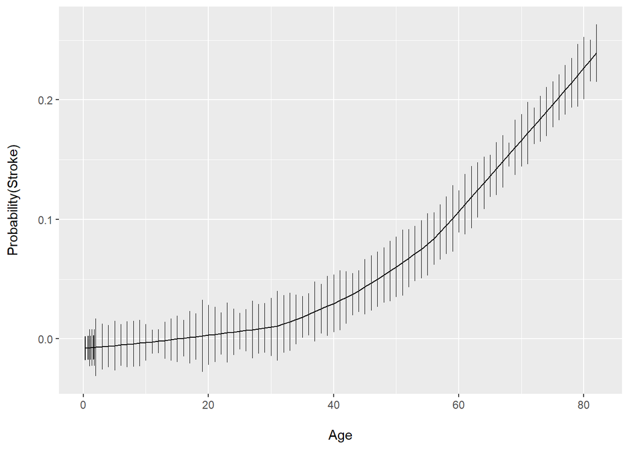

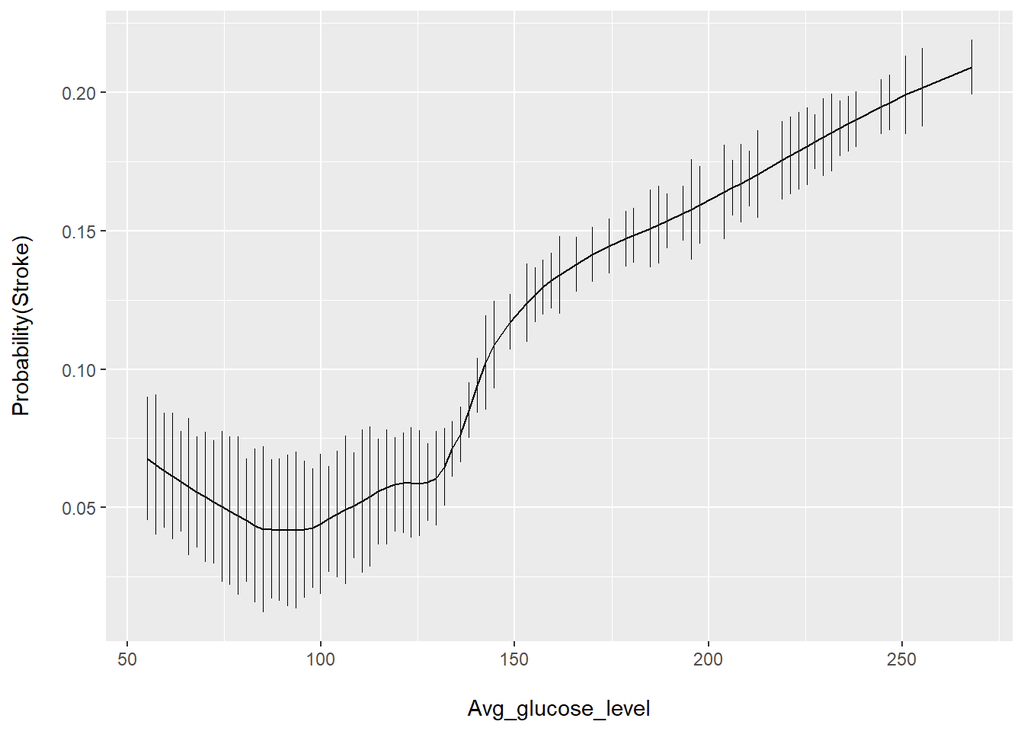

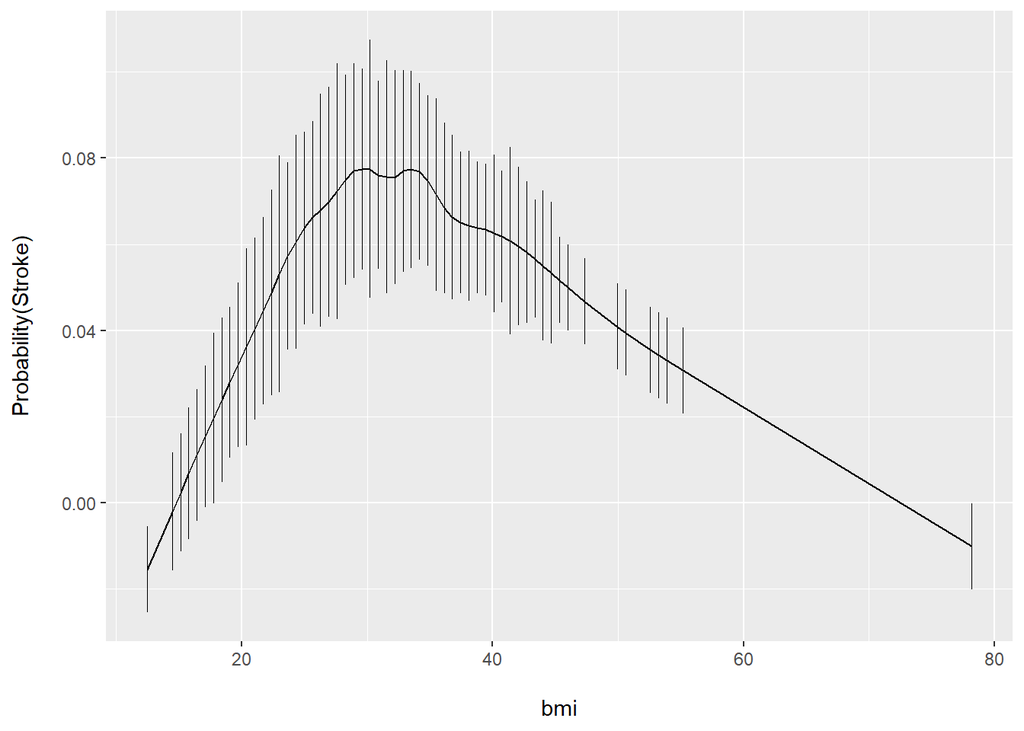

## Consider polynomial transformations for possible non-linearity

```
## Logistic Regression Model
##
##  lrm(formula = stroke ~ gender + age + hypertension + heart_disease +
##      ever_married + work_type + Residence_type + avg_glucose_level +
##      poly(bmi, 2) + smoking_status, data = dat)
##
##                       Model Likelihood    Discrimination    Rank Discrim.
##                             Ratio Test           Indexes          Indexes
##  Obs         502    LR chi2      70.43    R2       0.347    C       0.882
##   0          470    d.f.            16    g        3.078    Dxy     0.765
##   1           32    Pr(> chi2) <0.0001    gr      21.724    gamma   0.765
##  max |deriv| 0.1                          gp       0.092    tau-a   0.091
##                                           Brier    0.047
##
##                                 Coef     S.E.     Wald Z Pr(>|Z|)
##  Intercept                      -10.8031  28.5673 -0.38  0.7053
##  gender=Male                     -0.0326   0.4348 -0.08  0.9402
##  age                              0.0767   0.0182  4.22  <0.0001
##  hypertension=1                   1.4279   0.4421  3.23  0.0012
##  heart_disease=1                 -0.5060   0.6691 -0.76  0.4496
##  ever_married=Yes                 0.2588   0.7464  0.35  0.7288
##  work_type=Govt_job               2.0498  28.5946  0.07  0.9429
##  work_type=Never_worked          -1.8293 125.5180 -0.01  0.9884
##  work_type=Private                2.8017  28.5881  0.10  0.9219
##  work_type=Self-employed          1.4846  28.6012  0.05  0.9586
##  Residence_type=Urban             0.0261   0.4238  0.06  0.9508
##  avg_glucose_level                0.0072   0.0038  1.92  0.0550
##  1                               -4.2190   5.9992 -0.70  0.4819
##  2                                1.1474   7.7579  0.15  0.8824
##  smoking_status=formerly smoked   0.3099   0.4797  0.65  0.5183
##  smoking_status=smokes           -0.0495   0.6384 -0.08  0.9382
##  smoking_status=Unknown          -1.3903   0.8091 -1.72  0.0857
##
```

## Suspect interactions between the effect of age and other predictor variables…initial examination using Analysis of Variance

```
##              Df Sum Sq Mean Sq F value   Pr(>F)
## age           1  2.270  2.2696  40.845 3.79e-10 ***
## gender        1  0.011  0.0115   0.206    0.650
## age:gender    1  0.008  0.0075   0.135    0.713
## Residuals   498 27.672  0.0556
## ---
## Signif. codes:  0 '***' 0.001 '**' 0.01 '*' 0.05 '.' 0.1 ' ' 1
```

```
##                   Df Sum Sq Mean Sq F value   Pr(>F)
## age                1  2.270  2.2696  43.513 1.08e-10 ***
## hypertension       1  1.204  1.2043  23.090 2.05e-06 ***
## age:hypertension   1  0.511  0.5110   9.796  0.00185 **
## Residuals        498 25.975  0.0522
## ---
## Signif. codes:  0 '***' 0.001 '**' 0.01 '*' 0.05 '.' 0.1 ' ' 1
```

```
##              Df Sum Sq Mean Sq F value   Pr(>F)
## age           1  2.270  2.2696  40.980 3.56e-10 ***
## bmi           1  0.091  0.0909   1.641    0.201
## age:bmi       1  0.019  0.0194   0.350    0.554
## Residuals   498 27.580  0.0554
## ---
## Signif. codes:  0 '***' 0.001 '**' 0.01 '*' 0.05 '.' 0.1 ' ' 1
```

```
##                     Df Sum Sq Mean Sq F value   Pr(>F)
## age                  1  2.270  2.2696  41.760 2.48e-10 ***
## smoking_status       3  0.119  0.0396   0.729  0.53491
## age:smoking_status   3  0.724  0.2412   4.438  0.00432 **
## Residuals          494 26.848  0.0543
## ---
## Signif. codes:  0 '***' 0.001 '**' 0.01 '*' 0.05 '.' 0.1 ' ' 1
```

```
##                   Df Sum Sq Mean Sq F value   Pr(>F)
## age                1  2.270  2.2696  41.166 3.26e-10 ***
## ever_married       1  0.116  0.1158   2.101    0.148
## age:ever_married   1  0.119  0.1187   2.152    0.143
## Residuals        498 27.456  0.0551
## ---
## Signif. codes:  0 '***' 0.001 '**' 0.01 '*' 0.05 '.' 0.1 ' ' 1
```

```
##                     Df Sum Sq Mean Sq F value   Pr(>F)
## age                  1  2.270  2.2696  40.924 3.65e-10 ***
## Residence_type       1  0.040  0.0404   0.729    0.393
## age:Residence_type   1  0.032  0.0317   0.571    0.450
## Residuals          498 27.618  0.0555
## ---
## Signif. codes:  0 '***' 0.001 '**' 0.01 '*' 0.05 '.' 0.1 ' ' 1
```

```
##                    Df Sum Sq Mean Sq F value   Pr(>F)
## age                 1  2.270  2.2696  41.024 3.48e-10 ***
## heart_disease       1  0.011  0.0107   0.194    0.660
## age:heart_disease   1  0.129  0.1292   2.335    0.127
## Residuals         498 27.551  0.0553
## ---
## Signif. codes:  0 '***' 0.001 '**' 0.01 '*' 0.05 '.' 0.1 ' ' 1
```

```
##                        Df Sum Sq Mean Sq F value   Pr(>F)
## age                     1  2.270  2.2696  41.352 2.98e-10 ***
## avg_glucose_level       1  0.235  0.2348   4.277   0.0391 *
## age:avg_glucose_level   1  0.123  0.1234   2.249   0.1344
## Residuals             498 27.332  0.0549
## ---
## Signif. codes:  0 '***' 0.001 '**' 0.01 '*' 0.05 '.' 0.1 ' ' 1
```

```
##                Df Sum Sq Mean Sq F value  Pr(>F)
## age             1  2.270  2.2696  41.156 3.3e-10 ***
## work_type       4  0.472  0.1180   2.140  0.0748 .
## age:work_type   4  0.087  0.0218   0.395  0.8124
## Residuals     492 27.131  0.0551
## ---
## Signif. codes:  0 '***' 0.001 '**' 0.01 '*' 0.05 '.' 0.1 ' ' 1
```

```
## Logistic Regression Model
##
##  lrm(formula = stroke ~ gender + age + hypertension + heart_disease +
##      ever_married + work_type + Residence_type + avg_glucose_level +
##      bmi + smoking_status, data = dat, x = TRUE, y = TRUE)
##
##                       Model Likelihood    Discrimination    Rank Discrim.
##                             Ratio Test           Indexes          Indexes
##  Obs         502    LR chi2      70.41    R2       0.347    C       0.883
##   0          470    d.f.            15    g        3.077    Dxy     0.765
##   1           32    Pr(> chi2) <0.0001    gr      21.698    gamma   0.766
##  max |deriv| 0.1                          gp       0.092    tau-a   0.092
##                                           Brier    0.047
##
##                                 Coef     S.E.     Wald Z Pr(>|Z|)
##  Intercept                      -10.0142  28.4942 -0.35  0.7253
##  gender=Male                     -0.0419   0.4299 -0.10  0.9223
##  age                              0.0765   0.0181  4.22  <0.0001
##  hypertension=1                   1.4267   0.4421  3.23  0.0013
##  heart_disease=1                 -0.5116   0.6681 -0.77  0.4438
##  ever_married=Yes                 0.2515   0.7444  0.34  0.7355
##  work_type=Govt_job               1.9906  28.5189  0.07  0.9444
##  work_type=Never_worked          -1.8825 125.3725 -0.02  0.9880
##  work_type=Private                2.7465  28.5127  0.10  0.9233
##  work_type=Self-employed          1.4230  28.5253  0.05  0.9602
##  Residence_type=Urban             0.0301   0.4229  0.07  0.9433
##  avg_glucose_level                0.0072   0.0038  1.92  0.0548
##  bmi                             -0.0248   0.0361 -0.69  0.4923
##  smoking_status=formerly smoked   0.3094   0.4797  0.64  0.5190
##  smoking_status=smokes           -0.0471   0.6377 -0.07  0.9411
##  smoking_status=Unknown          -1.3908   0.8093 -1.72  0.0857
##
```

```
##                    gender=Male                            age
##                       1.074696                       1.269443
##                 hypertension=1                heart_disease=1
##                       1.063837                       1.127134
##               ever_married=Yes             work_type=Govt_job
##                       1.082521                    1857.247352
##         work_type=Never_worked              work_type=Private
##                       1.054430                    3804.569342
##        work_type=Self-employed           Residence_type=Urban
##                    2620.784865                       1.056078
##              avg_glucose_level                            bmi
##                       1.165669                       1.143184
## smoking_status=formerly smoked          smoking_status=smokes
##                       1.196847                       1.147793
##         smoking_status=Unknown
##                       1.107668
```

## Suspect interactions between the effect of age and two predictor variables

```
## Logistic Regression Model
##
##  lrm(formula = stroke ~ gender + age + hypertension + age * hypertension +
##      heart_disease + ever_married + work_type + Residence_type +
##      avg_glucose_level + bmi + smoking_status, data = dat)
##
##                       Model Likelihood    Discrimination    Rank Discrim.
##                             Ratio Test           Indexes          Indexes
##  Obs         502    LR chi2      70.45    R2       0.347    C       0.882
##   0          470    d.f.            16    g        3.059    Dxy     0.764
##   1           32    Pr(> chi2) <0.0001    gr      21.301    gamma   0.764
##  max |deriv| 0.1                          gp       0.092    tau-a   0.091
##                                           Brier    0.047
##
##                                 Coef     S.E.     Wald Z Pr(>|Z|)
##  Intercept                      -10.0106  28.4961 -0.35  0.7254
##  gender=Male                     -0.0391   0.4308 -0.09  0.9276
##  age                              0.0750   0.0194  3.87  0.0001
##  hypertension=1                   0.8706   2.7621  0.32  0.7526
##  heart_disease=1                 -0.5189   0.6715 -0.77  0.4397
##  ever_married=Yes                 0.2567   0.7491  0.34  0.7318
##  work_type=Govt_job               2.0748  28.5230  0.07  0.9420
##  work_type=Never_worked          -1.7756 119.2212 -0.01  0.9881
##  work_type=Private                2.8144  28.5159  0.10  0.9214
##  work_type=Self-employed          1.4705  28.5275  0.05  0.9589
##  Residence_type=Urban             0.0338   0.4239  0.08  0.9364
##  avg_glucose_level                0.0072   0.0038  1.90  0.0569
##  bmi                             -0.0239   0.0365 -0.66  0.5121
##  smoking_status=formerly smoked   0.3015   0.4818  0.63  0.5314
##  smoking_status=smokes           -0.0490   0.6382 -0.08  0.9388
##  smoking_status=Unknown          -1.4020   0.8114 -1.73  0.0840
##  age * hypertension=1             0.0083   0.0409  0.20  0.8382
##
```

```
## Logistic Regression Model
##
##  lrm(formula = stroke ~ gender + age + hypertension + age * smoking_status +
##      heart_disease + ever_married + work_type + Residence_type +
##      avg_glucose_level + bmi + smoking_status, data = dat)
##
##                       Model Likelihood    Discrimination    Rank Discrim.
##                             Ratio Test           Indexes          Indexes
##  Obs         502    LR chi2      72.61    R2       0.357    C       0.887
##   0          470    d.f.            18    g        3.154    Dxy     0.773
##   1           32    Pr(> chi2) <0.0001    gr      23.432    gamma   0.773
##  max |deriv| 0.1                          gp       0.093    tau-a   0.092
##                                           Brier    0.047
##
##                                       Coef     S.E.     Wald Z Pr(>|Z|)
##  Intercept                            -13.1276  28.8626 -0.45  0.6492
##  gender=Male                            0.0128   0.4343  0.03  0.9765
##  age                                    0.1016   0.0277  3.67  0.0002
##  hypertension=1                         1.5059   0.4542  3.32  0.0009
##  smoking_status=formerly smoked         3.9223   2.7162  1.44  0.1487
##  smoking_status=smokes                  2.6152   2.9718  0.88  0.3789
##  smoking_status=Unknown                 1.9245   4.0457  0.48  0.6343
##  heart_disease=1                       -0.4120   0.6683 -0.62  0.5376
##  ever_married=Yes                       0.3045   0.7650  0.40  0.6906
##  work_type=Govt_job                     3.4875  28.8043  0.12  0.9036
##  work_type=Never_worked                 0.2284 119.1924  0.00  0.9985
##  work_type=Private                      4.2049  28.7977  0.15  0.8839
##  work_type=Self-employed                2.8646  28.8067  0.10  0.9208
##  Residence_type=Urban                   0.0291   0.4256  0.07  0.9455
##  avg_glucose_level                      0.0071   0.0038  1.87  0.0611
##  bmi                                   -0.0282   0.0362 -0.78  0.4348
##  age * smoking_status=formerly smoked  -0.0548   0.0406 -1.35  0.1770
##  age * smoking_status=smokes           -0.0414   0.0460 -0.90  0.3686
##  age * smoking_status=Unknown          -0.0490   0.0593 -0.83  0.4084
##
```

## Stepwise Variable Selection

### perform backward stepwise variable selection - the final model should be adjusted later

```
##
##  Deleted           Chi-Sq d.f. P      Residual d.f. P      AIC
##  work_type         5.31   4    0.2572  5.31     4   0.2572  -2.69
##  smoking_status    3.73   3    0.2924  9.04     7   0.2501  -4.96
##  gender            0.00   1    0.9460  9.04     8   0.3389  -6.96
##  ever_married      0.04   1    0.8372  9.08     9   0.4297  -8.92
##  Residence_type    0.10   1    0.7526  9.18    10   0.5149 -10.82
##  bmi               0.29   1    0.5893  9.47    11   0.5783 -12.53
##  heart_disease     0.48   1    0.4867  9.96    12   0.6197 -14.04
##  avg_glucose_level 1.96   1    0.1618 11.91    13   0.5346 -14.09
##  hypertension      8.81   1    0.0030 20.73    14   0.1088  -7.27
##
## Approximate Estimates after Deleting Factors
##
##             Coef    S.E. Wald Z         P
## Intercept -6.281 1.07352  -5.85 4.901e-09
## age        0.069 0.01608   4.29 1.786e-05
##
## Factors in Final Model
##
## [1] age
```

## Final Model

```
## Logistic Regression Model
##
##  lrm(formula = stroke ~ age + hypertension, data = dat, x = TRUE,
##      y = TRUE)
##
##                         Model Likelihood    Discrimination    Rank Discrim.
##                               Ratio Test           Indexes          Indexes
##  Obs           502    LR chi2      55.78    R2       0.278    C       0.854
##   0            470    d.f.             2    g        1.923    Dxy     0.708
##   1             32    Pr(> chi2) <0.0001    gr       6.844    gamma   0.712
##  max |deriv| 9e-09                          gp       0.084    tau-a   0.085
##                                             Brier    0.051
##
##                 Coef    S.E.   Wald Z Pr(>|Z|)
##  Intercept      -6.7853 0.9496 -7.15  <0.0001
##  age             0.0667 0.0143  4.67  <0.0001
##  hypertension=1  1.3393 0.4140  3.23  0.0012
##
```

## Influential observation

```
## list()
```

```
## $Intercept
## [1] 138 141 247 437
##
## $age
## [1] 138 247 268 432 437
##
## $hypertension
## [1]  34  54 247
```

```
## Logistic Regression Model
##
##  lrm(formula = stroke ~ age + hypertension, data = dat_noinfl,
##      x = TRUE, y = TRUE)
##
##                         Model Likelihood    Discrimination    Rank Discrim.
##                               Ratio Test           Indexes          Indexes
##  Obs           495    LR chi2      52.11    R2       0.303    C       0.876
##   0            470    d.f.             2    g        2.301    Dxy     0.752
##   1             25    Pr(> chi2) <0.0001    gr       9.988    gamma   0.757
##  max |deriv| 3e-06                          gp       0.072    tau-a   0.072
##                                             Brier    0.040
##
##                 Coef    S.E.   Wald Z Pr(>|Z|)
##  Intercept      -8.0635 1.2637 -6.38  <0.0001
##  age             0.0824 0.0183  4.49  <0.0001
##  hypertension=1  1.2218 0.4611  2.65  0.0081
##
```

```
## Logistic Regression Model
##
##  lrm(formula = stroke ~ age + hypertension, data = dat, x = TRUE,
##      y = TRUE)
##
##                         Model Likelihood    Discrimination    Rank Discrim.
##                               Ratio Test           Indexes          Indexes
##  Obs           502    LR chi2      55.78    R2       0.278    C       0.854
##   0            470    d.f.             2    g        1.923    Dxy     0.708
##   1             32    Pr(> chi2) <0.0001    gr       6.844    gamma   0.712
##  max |deriv| 9e-09                          gp       0.084    tau-a   0.085
##                                             Brier    0.051
##
##                 Coef    S.E.   Wald Z Pr(>|Z|)
##  Intercept      -6.7853 0.9496 -7.15  <0.0001
##  age             0.0667 0.0143  4.67  <0.0001
##  hypertension=1  1.3393 0.4140  3.23  0.0012
##
```

## Model details

### Print probabilities of stroke by age and hypertension, including influential observations

```
##           age hypertension        yhat        lower       upper
## 1    1.638406            0 0.001259285 0.0002048590 0.007699133
## 2    2.037208            0 0.001293193 0.0002126533 0.007821255
## 3    2.436010            0 0.001328014 0.0002207429 0.007945339
## 4    2.834812            0 0.001363771 0.0002291391 0.008071417
## 5    3.233614            0 0.001400489 0.0002378532 0.008199521
## 6    3.632416            0 0.001438194 0.0002468974 0.008329685
## 7    4.031218            0 0.001476913 0.0002562840 0.008461944
## 8    4.430020            0 0.001516673 0.0002660260 0.008596331
## 9    4.828822            0 0.001557501 0.0002761365 0.008732883
## 10   5.227624            0 0.001599427 0.0002866296 0.008871635
## 11   5.626426            0 0.001642480 0.0002975195 0.009012623
## 12   6.025228            0 0.001686689 0.0003088212 0.009155886
## 13   6.424030            0 0.001732086 0.0003205502 0.009301460
## 14   6.822832            0 0.001778703 0.0003327224 0.009449385
```

[output cut: 390 more lines]

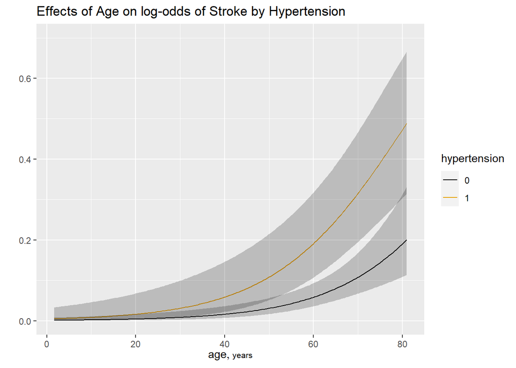

### Probability of stroke for team members’ age in different hypertesion status

```
##   age hypertension        yhat       lower      upper
## 1  22            0 0.004880582 0.001365091 0.01729268
## 2  25            0 0.005955519 0.001800450 0.01951219
## 3  32            0 0.009466514 0.003418348 0.02593733
## 4  22            1 0.018373263 0.004436866 0.07287999
## 5  25            1 0.022353177 0.005831793 0.08182704
## 6  32            1 0.035188978 0.010962460 0.10715438
##
## Response variable (y):
##
## Limits are 0.95 confidence limits
```

## Validating the model using the bootstrap to detect whether the model is overfitting the data

```
##
##      Backwards Step-down - Original Model
##
## No Factors Deleted
##
## Factors in Final Model
##
## [1] age          hypertension
```

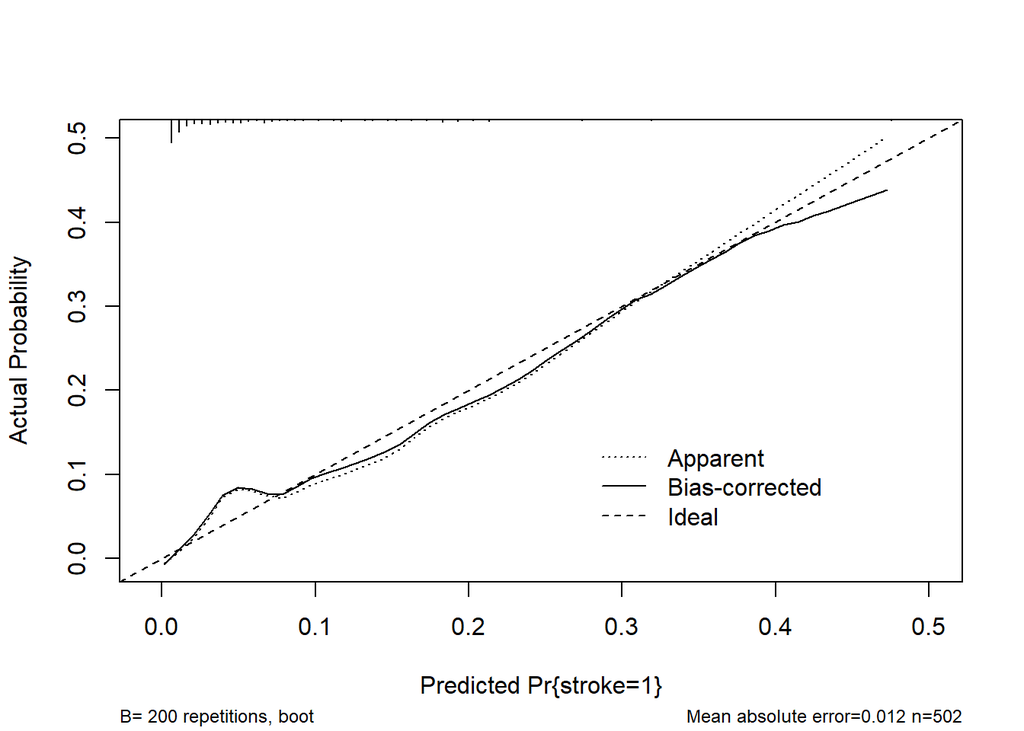

```
##
## n=502   Mean absolute error=0.012   Mean squared error=0.00024
## 0.9 Quantile of absolute error=0.029
```

```
##
##      Backwards Step-down - Original Model
##
## No Factors Deleted
##
## Factors in Final Model
##
## [1] age          hypertension
```

```
##           index.orig training   test optimism index.corrected   n
## Dxy            0.708    0.719  0.703    0.016           0.692 200
## R2             0.278    0.294  0.272    0.022           0.257 200
## Intercept      0.000    0.000 -0.070    0.070          -0.070 200
## Slope          1.000    1.000  0.958    0.042           0.958 200
## Emax           0.000    0.000  0.023    0.023           0.023 200
## D              0.109    0.116  0.107    0.010           0.099 200
## U             -0.004   -0.004  0.000   -0.004           0.000 200
## Q              0.113    0.120  0.106    0.014           0.099 200
## B              0.051    0.050  0.052   -0.002           0.053 200
## g              1.923    2.005  1.880    0.124           1.799 200
## gp             0.084    0.086  0.083    0.002           0.082 200
##
## Factors Retained in Backwards Elimination
##
##  age hypertension
##  *   *
##  *   *
##  *   *
##  *   *
##  *   *
##  *   *
##  *
##  *   *
##  *   *
##  *   *
##  *   *
##  *   *
##  *   *
##  *   *
##  *   *
##  *
##  *   *
##  *   *
##  *   *
##  *   *
##  *   *
##  *   *
##  *
##  *   *
```

[output cut: 16 more lines]

```
##  *   *
##  *   *
##  *   *
##  *   *
##  *   *
##  *   *
##  *   *
##  *   *
##  *   *
##  *   *
##
## Frequencies of Numbers of Factors Retained
##
##   1   2
##  11 189
```

### You can use the the optimism-corrected slope in the validate output to adjust the original prediction model for optimism

```
##                Original shrunk.boot
## Intercept        -6.785      -6.785
## age               0.067       0.064
## hypertension=1    1.339       1.284
```

## Alternative Model building

```
## Logistic Regression Model
##
##  lrm(formula = stroke ~ pc2, data = dat.pca)
##
##                         Model Likelihood    Discrimination    Rank Discrim.
##                               Ratio Test           Indexes          Indexes
##  Obs           502    LR chi2      39.41    R2       0.200    C       0.822
##   0            470    d.f.             2    g        1.701    Dxy     0.645
##   1             32    Pr(> chi2) <0.0001    gr       5.480    gamma   0.645
##  max |deriv| 9e-12                          gp       0.072    tau-a   0.077
##                                             Brier    0.056
##
##            Coef    S.E.   Wald Z Pr(>|Z|)
##  Intercept -3.4513 0.3272 -10.55 <0.0001
##  Comp.1    -0.9408 0.2134  -4.41 <0.0001
##  Comp.2     0.0486 0.1459   0.33 0.7390
##
```

```
## final_model     pc2_mod
##    188.3232    204.6855
```